[figure not shown]

Lagos Business School · Executive Education · Turning Data into Business Growth

# Strategy, value, and what AI actually changed

Day 1 · Frame it · Monday 12 October 2026

Prof. Bongo Adi · Lagos Business School

## The week

An assistant will write your query, fit your model and draft your memo in minutes.

It will not tell you the join doubled your Abuja revenue.

**This programme is about the part that did not get automated.**

## Who is in the room

**4**sector lenses

**Many**organisations

**44%**energy & extractives

**~1 in 2**ops, engineering, lab, risk, compliance or regulation

Energy & extractives 44%Pensions & public 24%Commercial 18%FS 13%

So this week **“growth”** also means barrels not deferred, cargoes not rejected, contributions recovered and revenue actually collected.

Every session ends with a *Now in your sector* slide. Two sector packs are in the data room: energy, and pensions & public sector.

## Before anything else: the daily one number

09:00 · 15 minutes

On the card in front of you, write:

1. **One number** you currently believe about your business.
2. **The interval** around it — the range you would bet inside, four times out of five.
3. **One sentence** on why you believe it.

Fold it. It is sealed until Friday morning.

**Facilitator** · Do not explain what the interval is for. If somebody asks how wide it should be, the answer is “as wide as you actually believe”. The discomfort is the content, and on Friday roughly two thirds of the room will find their interval was too narrow.

## Four mechanics run this week

### The four-minute rule

No demonstration runs for longer than four minutes before you do it yourselves. If we overrun, say so — that is a standing invitation, not a courtesy.

### Driver and Sceptic

You work in pairs and swap roles each day. The Driver has the keyboard. The Sceptic does not touch it, and must raise an objection *before* a result gets used rather than after.

### Salted data

The data room contains thirteen deliberate defects. They are not spread evenly — some files carry several and some are entirely clean.

You will present findings that turn out to be wrong. That is the design, and it is safe here.

### The failure logbook

Each table records what the assistant got wrong, and why. On Friday the entries become one page that everybody takes home.

## 1.1 · Competing on analytics

09:15 — 10:15 · Where the value actually comes from

## Three questions about your last dashboard

1. Which recurring decision does it exist to support?
2. Who makes that decision, how often, and what are their options?
3. What did they do differently after it was built?

## Why those questions are hard

A dashboard is nearly always specified by describing what it should **show** — revenue by region, margin by category, a trend line with last year behind it.

It is only rarely specified by describing what somebody should **do differently** once they can see it.

The first kind of specification is easy to write and easy to sign off. The second requires knowing whose job changes, which is a harder conversation to open — so it tends not to get opened.

## Analytics creates value in four ways

| # | Mechanism | Return | Spend |
| --- | --- | --- | --- |
| 1 | **Better recurring decisions** — pricing, replenishment, collections | Highest, compounding | Lowest |
| 2 | **Faster cycle time** — close in 4 days not 12 | High | Medium |
| 3 | **New revenue** — data products, risk-based pricing | High, slow | Medium |
| 4 | **Visibility** — “now we can see it” | Modest, and it decays | **Highest** |

Read the last two columns together. The mechanism with the highest return tends to attract the least spending, and the mechanism with the most modest return tends to attract the most.

## Visibility is worth something — and then it decays

You cannot manage what you cannot see, and the first credible dashboard in an organisation that has never had one genuinely changes behaviour. People look, they are surprised by something, and they act.

The difficulty is that the effect **decays**. Six months later it is open in a browser tab nobody reads, because seeing a number does not by itself tell anybody what to do about it.

The visibility was consumed. The decision was never redesigned.

## The test that separates them

Name the decision. Name the decision-maker. Name the frequency. Name the alternative action.

> *Depot managers reorder every Tuesday. Today they order to a fixed weeks-of-cover number. With this, they order to a forecast with a service-level target, and anything above 15% stockout risk gets flagged for expediting.*

If you cannot fill in all four blanks, you are building **visibility** — which is fine, as long as the business case is priced that way.

## Why the money goes to the wrong place

**Visibility is easier to specify.** “Revenue by region by month” is a complete requirement. “Depot managers order better” is a change programme.

**Visibility is easier to buy.** There is a vendor, a demo you can sit through, and a licence cost that fits on a budget line. There is no product that changes how somebody does their job.

**Visibility creates no loser.** Improving a recurring decision displaces somebody’s judgement — and that somebody is usually experienced, respected, and right often enough to have a real case for their method.

**The third one decides most outcomes.** Programmes that stall rarely stall on the mathematics. They stall here — which means it is an organisational question wearing technical clothing.

## Same structure, four sectors

|  | The decision | Today | With analytics |
| --- | --- | --- | --- |
| **FMCG** | Weekly reorder, 40 SKUs | Fixed cover, by feel | Forecast + service level |
| **Banking** | Who gets the retention call | Highest balance first | Highest *expected value at risk* |
| **Supply chain** | Which supplier gets volume | Unit price, relationship | Landed cost incl. lateness |
| **HR** | Where retention budget goes | Where attrition looks worst | Where it is expensive *and* preventable |

## Now in your sector · 1.1

Energy & extractives

Which well gets the workover crew this week? Ranking by expected restored barrels, not by who calls loudest, is mechanism 1. The morning production report is mechanism 4.

Data: energy_production_daily.csv

Pensions & public sector

Which employers get an enforcement visit this quarter? That decision turns a compliance dashboard into recovered contributions.

Data: pension_remittances.csv

Financial services

Who gets the collections call at a branch: the largest arrears, or the arrears most likely to cure because of the call?

Data: bank_customers.csv

Commercial & customer

Which distributor gets credit, which depot gets the promotion, which site gets capex: decisions, not reports.

Data: fmcg_sell_out.csv

## Lab 1.1

20 minutes · pairs

1. Each name one live analytics initiative in your organisation.
2. Classify it: decision / cycle-time / revenue / visibility.
3. Fill the four blanks. If you cannot, write the sentence that would have to become true.
4. **Sceptic:** name the person whose judgement this displaces, and what they will say.

**Stretch** · Rewrite it as mechanism 1 instead of 4. Same data, same budget. What has to change about *who receives the output and when*?

## 1.2 · The KPI tree

10:45 — 11:45 · From a P&L number to something somebody can change

## What a KPI tree is

Take a number nobody can act on directly — gross profit, say — and split it into the things that multiply or add up to it. Then split those, and keep going.

You stop when each branch reaches something a **named person** can change next week.

Gross profit → revenue and cost of goods → volume and price → depots, SKUs, promotions, and the availability of each line on the shelf.

## Decompose until somebody owns it

[figure not shown]

## Two failure modes kill most KPI frameworks

### The metric nobody owns

If the owner is recorded as “the business” or “the exec team”, nobody acts when it moves.

**One name. Not two.**

### The metric two teams define differently

Open `bank_customers.csv`.

Risk says **10.6%** churned. Finance says **15.9%**. They disagree about **633 customers**.

Neither definition is wrong. Both are in circulation, both are called “churn”, and the budget is set from one while the target is tracked against the other.

## Real or nominal — the fastest credibility win

| Measure | 2024 → 2025 |
| --- | --- |
| Revenue, nominal | **+42.8%** |
| Units | **+8.5%** |
| Avg. inflation 2025 | 25.3% |

Every nominal series is a currency story wearing a growth story’s clothes.

The follow-up question is the harder one: **deflated by what?**

**Facilitator** · This takes four seconds to ask and is almost never asked. In a Nigerian board room in 2026 it is the single fastest way to establish that you know what you are looking at.

## Now in your sector · 1.2

Energy & extractives

Revenue = wells on stream × rate × uptime × realised price − deferment. For a mine: tonnes milled × grade × recovery × price. Stop at the node an installation manager owns.

Data: energy_production_daily.csv

Pensions & public sector

Contributions collected = registered employers × compliance rate × employees × average contribution. For a revenue service, read IGR growth in real terms before anyone celebrates it.

Data: pension_remittances.csv + ng_macro_monthly.csv

Financial services

Microfinance yield = disbursement × portfolio yield × (1 − PAR30 loss). DuPont is the same tree for ROE.

Data: bank_customers.csv

Commercial & customer

Telecoms: subscribers × ARPU × (1 − churn). FMCG and cement: outlets × numeric distribution × rate of sale × price.

Data: fmcg_sell_out.csv

## Lab 1.2

30 minutes · pairs

1. Draw your KPI tree. Two levels minimum.
2. Mark every leaf a **named person** can change. Write the name.
3. Write the cadence. **Circle every weekly one** — that is your analytics shortlist.
4. Write a full definition card for the top node: metric, owner, definition, source, **excludes**, **changed**.
5. Ask a colleague from another function to state the same definition without seeing yours.

**Step 5 takes four minutes and is the whole lab.**

## 1.3 · Sizing the prize

11:45 — 12:45 · Defending a number you made up on purpose

## Every business case contains an invented number

Put it on one line, in front, with its assumptions named and a range around it.

**Value = Volume × Rate × Improvement × Unit economics**

Four of those five numbers come straight out of the data. **One is a judgement** — and at 15% the case is ₦14.8m, at 60% it is ₦59.1m.

## What the four terms actually mean

| Term | The question it answers | Where the number comes from |
| --- | --- | --- |
| **Volume** | How many opportunities are there in a year? | Counted. Depots × lines × weeks |
| **Rate** | What share of them currently go wrong? | Measured. The observed failure rate |
| **Improvement** | How much of that can you realistically fix? | Judged, and defensible against a benchmark |
| **Unit economics** | What is one fixed instance worth? | Measured revenue and margin, times a judgement |

Four terms, four different kinds of evidence. Knowing which term you are arguing about is most of the argument.

## Three assumptions. Exactly three.

Every value hypothesis gets three assumptions listed underneath it, ranked by how much the answer moves if they turn out to be wrong.

Three rather than seven, because a list of seven feels rigorous and functions as camouflage: with everything declared, nothing is emphasised, and the reader cannot tell which one to worry about.

Being held to three forces you to do the ranking yourself — and it turns *“do we believe this number?”* into *“how do we find out about assumption one?”*, which is a conversation that ends with somebody doing something.

**Facilitator** · Ask for a value case from the room and put it on the board. Strip it to one line. Then ask the room to name the three assumptions and rank them. Four minutes, then keys.

## Feasibility is not technical difficulty

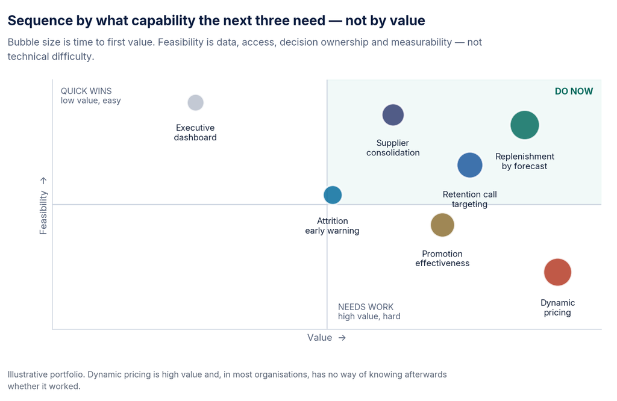

Feasibility here is organisational, not technical. The four questions that decide it are in the notes — and the last of them disqualifies more use cases than any modelling constraint.

## Now in your sector · 1.3

Energy & extractives

Value of one fewer day of unplanned downtime per quarter: barrels a day × price × days. Then the switching value: how wrong can the uptime gain be before the case flips?

Data: energy_production_daily.csv

Pensions & public sector

Value of recovering 10% of unremitted contributions, set against the cost of the visits. P10/P50/P90 is already the house language of energy, so borrow it.

Data: pension_remittances.csv

Financial services

One point off PAR30 × loan book × loss-given-default, stated as a range rather than a point.

Data: bank_customers.csv

Commercial & customer

One point of churn × ARPU × base, or 2% fewer stockouts × margin. Name the three assumptions.

Data: fmcg_sell_out.csv

## 1.4 · What AI actually changed

13:45 — 14:45 · The new division of labour

## The claim, stated narrowly

The cost of translating an intention into code has fallen by two orders of magnitude.

Nothing else about the work has changed at all.

That is enough to reorganise a profession, because translation into code *was* the barrier to entry — and everything on the other side of it was always the valuable part.

## Who does what now

| The work | Who | Why |
| --- | --- | --- |
| Writing a query from a description | **Assistant** | Syntax is solved |
| Knowing the right question | **You** | Needs the business and the decision |
| Cleaning and reshaping | **Assistant** | Pattern-matching |
| Knowing the data is wrong | **You** | Needs to know what the world looks like |
| Fitting a model | **Assistant** | Commoditised |
| Choosing what to model, and what “good” means | **You** | Commercial judgement |
| Drafting the memo | **Assistant** | Fast, competent, bland |
| Standing behind it on Friday | **You** | This is the job |

## The sentence for the week

An assistant is an outstanding generator

and a poor auditor of the question it was handed.

It answers what you asked, beautifully, whether or not that was worth asking and whether or not the data supports it. **It will not stop you.**

## Live: the query that is correct and wrong

four minutes, then keys

```sql
SELECT EXTRACT(year FROM week_starting) AS year,
       SUM(revenue_ngn) AS total_revenue
FROM 'fmcg_sell_out.csv'
GROUP BY 1 ORDER BY 1;
```

Correct. Well-formed. It runs. And it is the source of **four separate wrong conclusions.**

## One row per what?

**Grain** is the answer to a single question: what does one row of this table represent?

`fmcg_sell_out.csv` is one row per **depot, per SKU, per week**. Once you know that, three things become checkable in seconds:

- Whether any combination appears **twice**, which means something has been loaded more than once.
- Whether a total is a sum over the units you meant, or over some multiple of them.
- Whether a join has changed the count of rows — which it should not, if the other table has one row per thing.

It is the least glamorous idea in the programme and it prevents more expensive mistakes than anything else in it.

## Four questions. Ten seconds. Every dataset.

1. What is the **grain**? One row per what?
2. What **period** am I comparing to what period — are they the same length?
3. What is **missing**, and is missing the same as zero?
4. **Real or nominal** — and if real, deflated by what?

Four of the thirteen deliberate defects in this week’s data are caught by these alone.

## Now in your sector · 1.4

Energy & extractives

Inside the frontier: summarising shift handovers, HSE narratives and drafting SQL against a historian extract. Beyond it: reservoir or integrity judgement. Many operators block public assistants, so Tier 3 (local model) is your route.

Data: energy_lab_qc.csv

Pensions & public sector

Drafting circulars and summarising returns is fine. Contributor and taxpayer records never go into a public assistant. That is an NDPA question before it is a technical one.

Data: pension_complaints.csv

Financial services

Credit memos and KYC narratives: yes, with redaction. Customer data in a consumer tool: no.

Data: customer_reviews.csv

Commercial & customer

Campaign copy, review summaries and query drafts: high value, low risk. Pricing decisions: check the arithmetic yourself.

Data: customer_reviews.csv

## Lab 1.4

25 minutes · Driver on keys, Sceptic hands off

1. Ask the assistant for total revenue by year. Run what it gives you.
2. **Sceptic:** run the four questions aloud, one at a time. Driver fixes after each.
3. Get to a number you would both defend. Write down what changed.
4. Ask the assistant: *“what did you not check in your first answer?”* Compare its list to yours.
5. **First failure logbook entry.**

## 1.5 · Where the data lives

14:45 — 15:30 · Forty-five minutes, deliberately

## Five boxes. Every estate.

**Sources** → **Landing** → **Warehouse** → **Marts** → **Consumption**

**The warehouse box is where organisations argue**, because it is the only box where somebody has to decide what a customer *is*.

**Landing exists so that you can rebuild.** It looks like waste right up until a definition changes and you need the raw file again.

**Most organisations have this five times over.** Finance built one, Marketing built one, Digital built one. Each is internally coherent and none of them agree.

Facts *happen*; dimensions *exist*. And a real date table is worth building properly.

Open `fmcg_depots.csv`. **Count the depots. Count the rows.** Two minutes.

Whatever you find — do not fix it. Put it in the logbook and leave it there.

## Now in your sector · 1.5

Energy & extractives

Five boxes: historian/SCADA, maintenance (SAP PM), LIMS, production accounting, and the JV spreadsheets. Grain question: well-day or asset-month?

Data: energy_wells.csv

Pensions & public sector

Contributor databank, employer register, PFA returns, complaints system. Grain: contributor-month or employer-month?

Data: pension_employers.csv

Financial services

Core banking, loan management, CRM, AML. Grain: account or customer (BVN)?

Data: bank_customers.csv

Commercial & customer

Billing/CDRs, distributor management system, ERP. Grain: SIM or subscriber, depot or distributor?

Data: fmcg_depots.csv

## Lab 1 · The use-case charter

15:45 — 16:45

**5–30** Draft. Sceptic silent. Yes, really. **30–40** Attack. Sceptic takes it apart. Driver may only take notes. **40–52** Rewrite. **52–60** Pin to the wall. Read three others. Leave one written objection on each.

**Sceptic** · Find the ONE assumption that, if wrong, makes the charter worthless. Do not distribute your fire — a list of eight small objections is easier to survive than one unanswerable question.

## Close

Tomorrow the room stops taking numbers on trust.

Before you leave: charter on the wall · three objections left on other charters · failure logbook entry submitted · the number you now believe, with an interval, sealed.

If your laptop is managed by IT, talk to the floor technologist **now** rather than tomorrow morning.